# p8105_hw1_kpp2326

Kevin P. Patterson

2022-09-16

## Problem 1

```r
data("penguins", package = "palmerpenguins")
```

# Description

The penguins dataset contains 344 observations or individual penguin species. There are 8 variables, these variables detail the penguins’ measurements, sex, year, species, and island. Upon closer examination, the categorical variables islands, years, and species contain 3 islands (Biscoe, Dream, and Torgersen), 3 years (2007, 2008, and 2009), and 3 species (Adelie, Chinstrap, and Gentoo), respectively. The mean flipper length of penguins with available flipper length data is 201 mm.

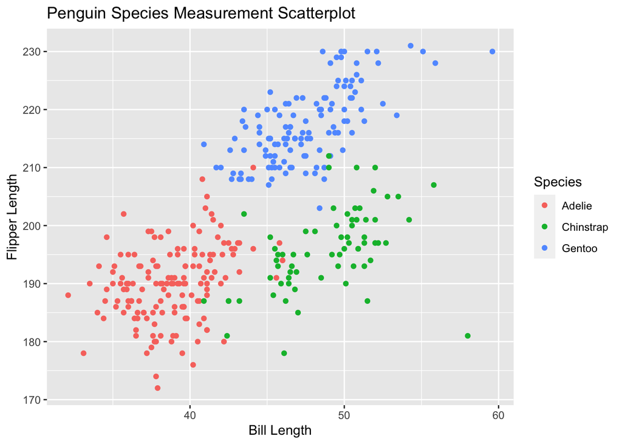

## Problem 2

```r
p2_df =
  tibble(
    p2_sample = rnorm(10),
    p2_sample_gtr0 = p2_sample > 0,
    p2_sample_ch = c("a", "b", "c", "d", "e", "f", "g", "h", "i", "j"),
    p2_sample_fct = factor(c("low","low","low","med","med","med","high","high","high","high"))
  )
```

```r
p2_df %>%
  summarise(across(where(is.numeric), mean))
```

```
## # A tibble: 1 × 1
##   p2_sample
##       <dbl>
## 1     0.421
```

```r
mean(pull(p2_df, p2_sample))
```

```
## [1] 0.4209401
```

```r
mean(pull(p2_df, p2_sample_gtr0))
```

```
## [1] 0.5
```

```r
mean(pull(p2_df, p2_sample_ch))
```

```
## [1] NA
```

```r
mean(pull(p2_df, p2_sample_fct))
```

```
## Warning in mean.default(pull(p2_df, p2_sample_fct)): argument is not numeric or
## logical: returning NA
```

```
## [1] NA
```

I tried to take the mean for columns that contained numeric values and as expected it only produced a mean for `p2_sample`. In addition to tidyverse, I separately pulled the means for all columns and my results were successful for `p2_sample`, again, and for `p2_sample_gtr0`, which produces a result based on the values that are TRUE since I created a logical vector for all values greater than 0, resulting in a binary of 0 and 1. For `p2_sample_ch` and `p2_sample_fct`, both resulted in warnings that indicated they’re neither numeric nor logical, further stating an NA.

```r
p2_df %>%
  dplyr::mutate_at(c('p2_sample', 'p2_sample_gtr0', 'p2_sample_ch', 'p2_sample_fct'), as.numeric)
```

```
## Warning in mask$eval_all_mutate(quo): NAs introduced by coercion
```

```r
as.numeric(pull(p2_df, p2_sample))
as.numeric(pull(p2_df, p2_sample_gtr0))
as.numeric(pull(p2_df, p2_sample_ch))
```

```
## Warning: NAs introduced by coercion
```

```r
as.numeric(pull(p2_df, p2_sample_fct))
```

I ran the conversion code first in tidyverse and separately using `as.numeric` for each variable, including the double coded variable `p2_sample` for consistency. The `p2_sample_gtr0` converted the logical vectors to numeric values for 0 and 1, which can no longer be interpreted with the logical argument for false and true values and instead taken as literal 0 and 1 numeric values. The `p2_sample_ch` did not convert since they are characters and resulted in a warning and NAs. The `p2_sample_fct` converted the previously coded factor levels to 1 (high), 2 (low) and 3 (med). The numbers were assigned based on alphabetical order.

This helps explains why the mean can’t be taken when it’s a character or a factor, because they are not coded as real numbers or logical vectors (denoting 0, false or 1, true).